# Prediction Assignmet: Human activity recognition

Alessandro

10/30/2020

## Overview

The goal of this project is to predict the manner in which some people did an exercise.

## Data input and cleaning

The input data are downloded and loaded in the two data frame ‘d_train’ and ‘d_test’

```r
fileUrl <- "https://d396qusza40orc.cloudfront.net/predmachlearn/pml-training.csv"
download.file(fileUrl, destfile = "./training.csv", method = "curl")
d_train <- read.csv("training.csv")

fileUrl <- "https://d396qusza40orc.cloudfront.net/predmachlearn/pml-testing.csv"
download.file(fileUrl, destfile = "./testing.csv", method = "curl")
d_test <- read.csv("testing.csv")
```

The first columns of the data set seems to be potential counfounders, especially X is a progressive number that could be strongly correlated with the outcome without to be a causal variable. So the first 6 colums are eliminated.

```r
d_train <- d_train[,-(1:6)]
d_test <- d_test[ , -(1:6)]
```

the training set appear to be full of missing data and many numeric column have been converted in factors because a division by zero made the character string #DIV/0! to be included.

```r
sum(is.na(d_train))
```

```
## [1] 1287472
```

```r
dim(d_train)
```

```
## [1] 19622   154
```

In order to take advantage of the maximum information I followed two strategies. The training set is divided in two subsets

### First strategy (all possible consistent variables)

I consider a first subset called ‘sub_train’ that include all variables but without missing values for each observation line and I eliminate also possible constant columns and the strings #DIV/0! that will be converted in NA due to the conversion from factor to numeric of the column they belonged.

```r
# Missing values elimination
sub_train <- d_train[complete.cases(d_train),]
# Eliminitaion of constant columns
sub_train <- sub_train[,(apply(sub_train, 2, function(x) !(length(unique(x)) == 1)))]
dim(sub_train)
```

```
## [1] 406 148
```

```r
# conversion from factor to numeric (they have been originally unintentionally  converted in factor by the presence of a character string)
for (i in 1:length(sub_train[1,])) {
    if ("#DIV/0!" %in% sub_train[,i]) {
        sub_train[,i] <- as.numeric(as.character(sub_train[,i]))
    }
}
# The missing value generated by the above conversion are still eliminated and again all possible constant columns
sub_train <- sub_train[complete.cases(sub_train),]
sub_train <- sub_train[,(apply(sub_train, 2, function(x) !(length(unique(x)) == 1)))]
dim(sub_train)
```

```
## [1] 217 145
```

It’s worth noting that now the data set dimension reduced a lot the observations from 19622 to 217 with a small reduction in the variable numbers from 160 to 145. A similar operation is performed on the d_test data set obtaining ‘sub_test’ data set.

```r
sub_test <- d_test[,names(sub_train[,1:144])]
# all NA are replaced with 0
for (i in 1:length(sub_test[1,])) {
    if (NA %in% sub_test[,i]) {
        sub_test[,i] <- 0
    }
}
```

### Second Strategy (all possible observations)

A second sub data set has been obtained as the complement of the previous one. That is, the data set ‘comp_train’. (see code and comments below)

```r
# comp_train represent all complementary information to sub_train
comp_train <- d_train[!complete.cases(d_train),]
dim(comp_train)
```

```
## [1] 19216   154
```

```r
# Now all the columns including (only) missing values or constant are eliminated
comp_train <- comp_train[,apply(comp_train, 2, function(x) !all(is.na(x)))]
comp_train <- comp_train[,apply(comp_train, 2, function(x) !all(x == ""))]
comp_train <- comp_train[,apply(comp_train, 2, function(x) !(length(unique(x)) == 1))]
dim(comp_train)
```

```
## [1] 19216    54
```

```r
# This is the correspondent data set for test
comp_test <- d_test[,names(comp_train[,1:53])]
```

Now in this subset we have many observation (19216) but very few variables (54). However they are now two clean data set and I processed both to select later the better strategy.

Concerning the predition algorithms, I tested many methods but, for sake of simplicity, I reports only two cases:

- a classification tree based on the principal component analysis prepocessing with 6 different levels of complexity.
- the best tradeoff I found in terms of accuracy and exceution time, that is the bagging algorithm based on “treebag” method

### Prediction (Classification tree “rpart” with PCA preprocessing)

The cross validation is performed by the trainControl() function setting 10 folds with the default partition of p = 75%. Both sub data sets ‘comp_train’ and ‘sub_train’ have been processed.

```r
library(caret)
```

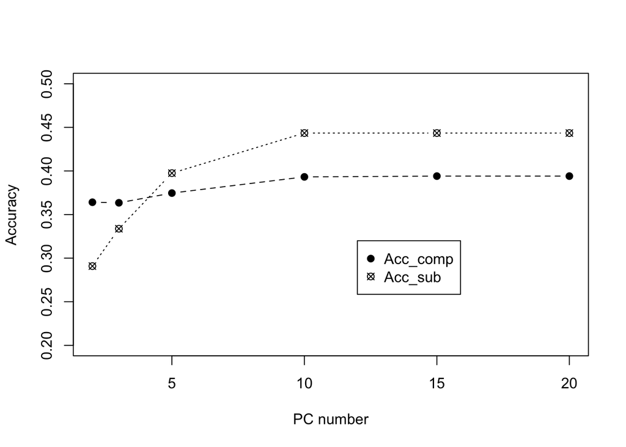

```r
pca_set <- c(2,3,5,10,15,20)
accuracy_c <- rep(0,6)
accuracy_s <- rep(0,6)
trCo <- trainControl(method = "cv",savePredictions = T,number = 10)
for ( i in 1:6) {
    set.seed(123)
    preproc <- preProcess(comp_train[,-54], method = "pca", pcaComp = pca_set[i])
    comp_trainPC <- predict(preproc,comp_train[,-54])
    comp_trainPC <- cbind(comp_trainPC,classe = comp_train$classe)
    modcomp5 <- train(classe ~ ., method = "rpart", data = comp_trainPC,
                      trControl = trCo)

    accuracy_c[i] <- modcomp5$result[modcomp5$result$cp==modcomp5$bestTune[1,1],2]

    set.seed(123)
    preproc <- preProcess(sub_train[,-145], method = "pca",
                          pcaComp = pca_set[i])
    sub_trainPC <- predict(preproc,sub_train[,-145])
    sub_trainPC <- cbind(sub_trainPC,classe = sub_train$classe)
    modsub5 <- train(classe ~ ., method = "rpart", data = sub_trainPC,
                     trControl = trCo)
    accuracy_s[i] <- modsub5$result[modsub5$result$cp==modsub5$bestTune[1,1],2]
}
plot(pca_set,accuracy_c,type = "b", lty=2, ylim = c(0.2,0.5),
     ylab = "Accuracy",
     xlab = "PC number", pch=19)
lines(pca_set,accuracy_s,type = "b", lty=3, pch= 13)
legend(12,0.32, c("Acc_comp","Acc_sub"), pch = c(19,13))
```

From the figure we can see that the accuracy related to the first data cleaning strategy, (Acc_sub <-> all possible variables), becomes better for principal components equal or greater than 5 but in both cases the accuracy doesn’t improve for PC > 10. In any case the accuracy doesn’t reach a satisfactory level.

### Prediction (Bagging)

The cross validation is always performed by the trainControl(), furthermore setting the option savePredictions = T, observations (obs) and predictions (pred) from the cross validation process are available from the model with the field ‘pred’ (see below the code for ‘predsubt’). This is based on the first strategy data set ‘sub_train’ (all possible variables)

```r
trCo <- trainControl(method = "cv",savePredictions = T,number = 10)
set.seed(123)
modsub3 <- train(classe ~ ., method = "treebag", data = sub_train,
                 trControl = trCo)
modsub3
```

```
## Bagged CART
##
## 217 samples
## 144 predictors
##   5 classes: 'A', 'B', 'C', 'D', 'E'
##
## No pre-processing
## Resampling: Cross-Validated (10 fold)
## Summary of sample sizes: 196, 194, 194, 196, 196, 194, ...
## Resampling results:
##
##   Accuracy   Kappa
##   0.7788716  0.7210159
```

```r
predsubt <- modsub3$pred
confusionMatrix(predsubt$pred,predsubt$obs)
```

```
## Confusion Matrix and Statistics
##
##           Reference
## Prediction  A  B  C  D  E
##          A 45 10  7  4  3
##          B  4 33  4  1  1
##          C  2  3 26  2  2
##          D  2  1  0 28  0
##          E  1  1  0  0 37
##
## Overall Statistics
##
##                Accuracy : 0.7788
##                  95% CI : (0.7176, 0.8322)
##     No Information Rate : 0.2488
##     P-Value [Acc > NIR] : < 2.2e-16
##
##                   Kappa : 0.7203
##
##  Mcnemar's Test P-Value : NA
##
## Statistics by Class:
##
##                      Class: A Class: B Class: C Class: D Class: E
## Sensitivity            0.8333   0.6875   0.7027   0.8000   0.8605
## Specificity            0.8528   0.9408   0.9500   0.9835   0.9885
## Pos Pred Value         0.6522   0.7674   0.7429   0.9032   0.9487
## Neg Pred Value         0.9392   0.9138   0.9396   0.9624   0.9663
## Prevalence             0.2488   0.2212   0.1705   0.1613   0.1982
## Detection Rate         0.2074   0.1521   0.1198   0.1290   0.1705
## Detection Prevalence   0.3180   0.1982   0.1613   0.1429   0.1797
## Balanced Accuracy      0.8430   0.8142   0.8264   0.8918   0.9245
```

The accuracy level seems better than before but let’s see the behaviour related to the second strategy (all possible observations)

```r
set.seed(123)
modcomp3 <- train(classe ~ ., method = "treebag", data = comp_train,
                  trControl = trCo)
modcomp3
```

```
## Bagged CART
##
## 19216 samples
##    53 predictor
##     5 classes: 'A', 'B', 'C', 'D', 'E'
##
## No pre-processing
## Resampling: Cross-Validated (10 fold)
## Summary of sample sizes: 17293, 17296, 17295, 17294, 17294, 17295, ...
## Resampling results:
##
##   Accuracy   Kappa
##   0.9959929  0.9949309
```

```r
predcompt <- modcomp3$pred
confusionMatrix(predcompt$pred,predcompt$obs)
```

```
## Confusion Matrix and Statistics
##
##           Reference
## Prediction    A    B    C    D    E
##          A 5466   15    0    0    1
##          B    3 3691    8    5    5
##          C    1   10 3338   14    0
##          D    0    1    6 3127    5
##          E    1    1    0    1 3517
##
## Overall Statistics
##
##                Accuracy : 0.996
##                  95% CI : (0.995, 0.9968)
##     No Information Rate : 0.2847
##     P-Value [Acc > NIR] : < 2.2e-16
##
##                   Kappa : 0.9949
##
##  Mcnemar's Test P-Value : NA
##
## Statistics by Class:
##
##                      Class: A Class: B Class: C Class: D Class: E
## Sensitivity            0.9991   0.9927   0.9958   0.9936   0.9969
## Specificity            0.9988   0.9986   0.9984   0.9993   0.9998
## Pos Pred Value         0.9971   0.9943   0.9926   0.9962   0.9991
## Neg Pred Value         0.9996   0.9983   0.9991   0.9988   0.9993
## Prevalence             0.2847   0.1935   0.1744   0.1638   0.1836
## Detection Rate         0.2845   0.1921   0.1737   0.1627   0.1830
## Detection Prevalence   0.2853   0.1932   0.1750   0.1634   0.1832
## Balanced Accuracy      0.9990   0.9957   0.9971   0.9964   0.9983
```

These results are much better than the previous case! The accuracy is = 0.996 even if the variales are ony 54 (rather than 145). In this case even if many information types have been removed, the big amount of observations seems to highly overcompensate this lack.

## Testing

```r
print("Result prediction with treebag model based on data set comp_test")
```

```
## [1] "Result prediction with treebag model based on data set comp_test"
```

```r
predict(modcomp3,comp_test)
```

```
##  [1] B A B A A E D B A A B C B A E E A B B B
## Levels: A B C D E
```